# PRS training progress

#### Fold 1 analysis results (partial) for CC4D+BBJ_MCPS, first 20 rows

| parameters | OR | LR | UR | AUC | AUC_LR | AUC_UR | Nagelkerke_PseudoR2 | lee_PseudoR2 | case_no | control_no | pval | se |
| --- | --- | --- | --- | --- | --- | --- | --- | --- | --- | --- | --- | --- |
| grid_norm_p_0.0105_h2_0.01_FALSE | 1.2863 | 1.1595 | 1.4269 | 0.7314 | 0.7090 | 0.7537 | 0.0821 | 0.1528 | 378 | 10319 | 1.988e-06 | 0.05294606 |
| grid_norm_p_0.0155_h2_0.015_TRUE | 1.2801 | 1.1536 | 1.4205 | 0.7314 | 0.7091 | 0.7536 | 0.0818 | 0.1521 | 378 | 10319 | 3.3e-06 | 0.05309277 |
| grid_norm_p_0.0255_h2_0.025_TRUE | 1.2752 | 1.1489 | 1.4154 | 0.7314 | 0.7093 | 0.7536 | 0.0815 | 0.1517 | 378 | 10319 | 4.894e-06 | 0.05320559 |
| grid_norm_p_0.0055_h2_0.01_TRUE | 1.2893 | 1.1623 | 1.4300 | 0.7313 | 0.7089 | 0.7536 | 0.0823 | 0.1528 | 378 | 10319 | 1.544e-06 | 0.05287017 |
| grid_norm_p_0.0205_h2_0.015_TRUE | 1.2786 | 1.1522 | 1.4190 | 0.7313 | 0.7091 | 0.7536 | 0.0817 | 0.1521 | 378 | 10319 | 3.721e-06 | 0.05312994 |
| grid_norm_p_0.0155_h2_0.02_TRUE | 1.2776 | 1.1513 | 1.4177 | 0.7313 | 0.7091 | 0.7535 | 0.0816 | 0.1519 | 378 | 10319 | 3.982e-06 | 0.05311223 |
| grid_norm_p_0.0205_h2_0.02_TRUE | 1.2772 | 1.1508 | 1.4174 | 0.7313 | 0.7090 | 0.7535 | 0.0816 | 0.1520 | 378 | 10319 | 4.156e-06 | 0.05314240 |
| grid_norm_p_0.0255_h2_0.02_TRUE | 1.2718 | 1.1458 | 1.4117 | 0.7313 | 0.7091 | 0.7535 | 0.0813 | 0.1515 | 378 | 10319 | 6.245e-06 | 0.05322450 |
| grid_norm_p_0.0305_h2_0.02_TRUE | 1.2696 | 1.1437 | 1.4094 | 0.7313 | 0.7091 | 0.7534 | 0.0812 | 0.1513 | 378 | 10319 | 7.485e-06 | 0.05328843 |
| grid_meta_p_0.0105_h2_0.01_TRUE | 1.2878 | 1.1608 | 1.4286 | 0.7313 | 0.7090 | 0.7537 | 0.0822 | 0.1528 | 378 | 10319 | 1.786e-06 | 0.05295000 |
| grid_meta_p_0.0105_h2_0.015_TRUE | 1.2853 | 1.1585 | 1.4260 | 0.7313 | 0.7090 | 0.7537 | 0.0820 | 0.1525 | 378 | 10319 | 2.169e-06 | 0.05298849 |
| grid_meta_p_0.0155_h2_0.02_TRUE | 1.2770 | 1.1509 | 1.4170 | 0.7313 | 0.7090 | 0.7535 | 0.0816 | 0.1519 | 378 | 10319 | 4.071e-06 | 0.05306467 |
| grid_meta_p_0.0205_h2_0.02_TRUE | 1.2794 | 1.1528 | 1.4199 | 0.7313 | 0.7090 | 0.7535 | 0.0817 | 0.1520 | 378 | 10319 | 3.558e-06 | 0.05315523 |
| grid_norm_p_0.0105_h2_0.01_TRUE | 1.2849 | 1.1582 | 1.4255 | 0.7312 | 0.7088 | 0.7536 | 0.0820 | 0.1526 | 378 | 10319 | 2.23e-06 | 0.05298490 |
| grid_norm_p_0.0105_h2_0.015_TRUE | 1.2798 | 1.1536 | 1.4199 | 0.7312 | 0.7090 | 0.7535 | 0.0818 | 0.1521 | 378 | 10319 | 3.218e-06 | 0.05298915 |
| grid_norm_p_0.0255_h2_0.015_TRUE | 1.2715 | 1.1455 | 1.4113 | 0.7312 | 0.7090 | 0.7534 | 0.0813 | 0.1513 | 378 | 10319 | 6.442e-06 | 0.05323418 |
| grid_norm_p_0.0405_h2_0.02_TRUE | 1.2611 | 1.1360 | 1.4001 | 0.7312 | 0.7091 | 0.7533 | 0.0808 | 0.1505 | 378 | 10319 | 1.358e-05 | 0.05333203 |
| grid_norm_p_0.0205_h2_0.025_TRUE | 1.2702 | 1.1444 | 1.4098 | 0.7312 | 0.7090 | 0.7533 | 0.0813 | 0.1512 | 378 | 10319 | 6.928e-06 | 0.05319699 |
| grid_norm_p_0.0355_h2_0.025_TRUE | 1.2639 | 1.1385 | 1.4031 | 0.7312 | 0.7091 | 0.7533 | 0.0810 | 0.1507 | 378 | 10319 | 1.118e-05 | 0.05330973 |
| grid_norm_p_0.0255_h2_0.03_TRUE | 1.2673 | 1.1418 | 1.4067 | 0.7312 | 0.7092 | 0.7533 | 0.0811 | 0.1512 | 378 | 10319 | 8.558e-06 | 0.05322615 |

After repeating this for each fold

#### mean AUC (partial adjustments) for CC4D+BBJ_MCPS, first 20 rows

Due to non-convergence, I also summed up how many folds missing in na_sum, if there is 1 fold AUC missing, the parameter will not be carried forward for comparison

| parameter | AUC1 | AUC2 | AUC3 | AUC4 | AUC5 | AUC6 | AUC7 | AUC8 | AUC9 | AUC10 | na_sum | meanAUC |
| --- | --- | --- | --- | --- | --- | --- | --- | --- | --- | --- | --- | --- |
| grid_meta_p_0.1155_h2_0.05_TRUE | 0.7307 | 0.7362 | 0.7410 | 0.7219 | 0.7400 | 0.7407 | 0.7111 | 0.7110 | 0.7584 | 0.7418 | 0 | 0.73328 |
| grid_norm_p_0.0805_h2_0.05_TRUE | 0.7309 | 0.7357 | 0.7407 | 0.7216 | 0.7400 | 0.7406 | 0.7119 | 0.7108 | 0.7589 | 0.7416 | 0 | 0.73327 |
| grid_meta_p_0.0955_h2_0.055_TRUE | 0.7306 | 0.7361 | 0.7408 | 0.7218 | 0.7397 | 0.7407 | 0.7112 | 0.7112 | 0.7588 | 0.7417 | 0 | 0.73326 |
| grid_norm_p_0.0555_h2_0.045_TRUE | 0.7305 | 0.7356 | 0.7406 | 0.7215 | 0.7399 | 0.7406 | 0.7126 | 0.7103 | 0.7596 | 0.7413 | 0 | 0.73325 |
| grid_meta_p_0.0805_h2_0.045_TRUE | 0.7310 | 0.7359 | 0.7405 | 0.7213 | 0.7401 | 0.7407 | 0.7119 | 0.7106 | 0.7589 | 0.7416 | 0 | 0.73325 |
| grid_meta_p_0.0805_h2_0.05_TRUE | 0.7309 | 0.7356 | 0.7408 | 0.7216 | 0.7400 | 0.7407 | 0.7116 | 0.7106 | 0.7590 | 0.7417 | 0 | 0.73325 |
| grid_norm_p_0.1205_h2_0.06_TRUE | 0.7308 | 0.7359 | 0.7406 | 0.7217 | 0.7398 | 0.7407 | 0.7113 | 0.7115 | 0.7584 | 0.7418 | 0 | 0.73325 |
| grid_meta_p_0.0905_h2_0.05_TRUE | 0.7307 | 0.7360 | 0.7409 | 0.7215 | 0.7400 | 0.7407 | 0.7115 | 0.7108 | 0.7587 | 0.7417 | 0 | 0.73325 |
| grid_norm_p_0.1055_h2_0.055_TRUE | 0.7303 | 0.7363 | 0.7409 | 0.7216 | 0.7400 | 0.7406 | 0.7114 | 0.7110 | 0.7587 | 0.7417 | 0 | 0.73325 |
| grid_norm_p_0.0955_h2_0.055_TRUE | 0.7308 | 0.7357 | 0.7409 | 0.7218 | 0.7397 | 0.7407 | 0.7115 | 0.7111 | 0.7588 | 0.7414 | 0 | 0.73324 |
| grid_norm_p_0.0705_h2_0.05_TRUE | 0.7307 | 0.7360 | 0.7407 | 0.7217 | 0.7398 | 0.7407 | 0.7119 | 0.7106 | 0.7587 | 0.7416 | 0 | 0.73324 |
| grid_norm_p_0.0955_h2_0.045_TRUE | 0.7308 | 0.7360 | 0.7407 | 0.7215 | 0.7399 | 0.7406 | 0.7115 | 0.7106 | 0.7590 | 0.7417 | 0 | 0.73323 |
| grid_meta_p_0.0805_h2_0.04_TRUE | 0.7308 | 0.7356 | 0.7411 | 0.7211 | 0.7401 | 0.7407 | 0.7124 | 0.7101 | 0.7589 | 0.7415 | 0 | 0.73323 |
| grid_meta_p_0.0755_h2_0.05_TRUE | 0.7308 | 0.7359 | 0.7408 | 0.7216 | 0.7399 | 0.7407 | 0.7114 | 0.7105 | 0.7591 | 0.7416 | 0 | 0.73323 |
| grid_meta_p_0.0855_h2_0.04_TRUE | 0.7307 | 0.7359 | 0.7409 | 0.7215 | 0.7401 | 0.7407 | 0.7119 | 0.7102 | 0.7588 | 0.7416 | 0 | 0.73323 |
| grid_norm_p_0.1005_h2_0.045_TRUE | 0.7309 | 0.7359 | 0.7410 | 0.7215 | 0.7399 | 0.7407 | 0.7113 | 0.7107 | 0.7586 | 0.7417 | 0 | 0.73322 |
| grid_norm_p_0.0655_h2_0.045_TRUE | 0.7307 | 0.7357 | 0.7406 | 0.7216 | 0.7399 | 0.7407 | 0.7120 | 0.7105 | 0.7589 | 0.7415 | 0 | 0.73321 |
| grid_meta_p_0.0655_h2_0.04_TRUE | 0.7307 | 0.7356 | 0.7410 | 0.7213 | 0.7401 | 0.7407 | 0.7122 | 0.7101 | 0.7590 | 0.7414 | 0 | 0.73321 |
| grid_meta_p_0.0705_h2_0.04_TRUE | 0.7306 | 0.7360 | 0.7407 | 0.7214 | 0.7401 | 0.7407 | 0.7122 | 0.7101 | 0.7590 | 0.7413 | 0 | 0.73321 |
| grid_meta_p_0.1055_h2_0.045_TRUE | 0.7306 | 0.7358 | 0.7409 | 0.7216 | 0.7400 | 0.7407 | 0.7117 | 0.7106 | 0.7585 | 0.7417 | 0 | 0.73321 |

#### mean AUC for all gwas combinations, first 20 rows

**Full adjustments**

| parameter | meanAUC_cc4d_bbj | na_sum_cc4d_bbj | meanAUC_ukb_cc4d | na_sum_ukb_cc4d | meanAUC_ukb_cc4d_bbj | na_sum_ukb_cc4d_bbj | meanAUC_ukb_ckb | na_sum_ukb_ckb | meanAUC_ukb_ckb_cc4d_bbj | na_sum_ukb_ckb_cc4d_bbj | na_gwas_sum |
| --- | --- | --- | --- | --- | --- | --- | --- | --- | --- | --- | --- |
| grid_meta_p_0.0405_h2_0.035_TRUE | 0.76201 | 0 | 0.7614400 | 0 |  |  | 0.76153 | 0 |  |  | 2 |
| grid_meta_p_0.0305_h2_0.03_TRUE | 0.76200 | 0 | 0.7614300 | 0 |  |  | 0.76146 | 0 |  |  | 2 |
| grid_norm_p_0.0355_h2_0.035_TRUE | 0.76200 | 0 | 0.7648556 | 1 |  |  | 0.76152 | 0 |  |  | 2 |
| grid_norm_p_0.0305_h2_0.025_TRUE | 0.76198 | 0 | 0.7614200 | 0 |  |  | 0.76144 | 0 |  |  | 2 |
| grid_norm_p_0.0355_h2_0.03_TRUE | 0.76198 | 0 | 0.7614600 | 0 |  |  | 0.76149 | 0 |  |  | 2 |
| grid_norm_p_0.0255_h2_0.03_TRUE | 0.76197 | 0 | 0.7616333 | 1 |  |  | 0.76152 | 0 |  |  | 2 |
| grid_norm_p_0.0505_h2_0.03_TRUE | 0.76197 | 0 | 0.7614600 | 0 |  |  | 0.76146 | 0 |  |  | 2 |
| grid_norm_p_0.0505_h2_0.035_TRUE | 0.76197 | 0 | 0.7614500 | 0 |  |  | 0.76157 | 0 |  |  | 2 |
| grid_norm_p_0.0255_h2_0.025_TRUE | 0.76196 | 0 | 0.7613700 | 0 |  |  | 0.76144 | 0 |  |  | 2 |
| grid_meta_p_0.0255_h2_0.025_TRUE | 0.76195 | 0 | 0.7613500 | 0 |  |  | 0.76143 | 0 |  |  | 2 |
| grid_meta_p_0.0255_h2_0.03_TRUE | 0.76195 | 0 | 0.7603667 | 1 |  |  | 0.76145 | 0 |  |  | 2 |
| grid_norm_p_0.0555_h2_0.04_TRUE | 0.76195 | 0 | 0.7615100 | 0 |  |  | 0.76155 | 0 |  |  | 2 |
| grid_norm_p_0.0555_h2_0.045_TRUE | 0.76195 | 0 |  |  |  |  | 0.76155 | 0 |  |  | 3 |
| grid_meta_p_0.0455_h2_0.025_TRUE | 0.76194 | 0 | 0.7614400 | 0 | 0.76241 | 0 | 0.76141 | 0 | 0.763825 | 6 | 0 |
| grid_meta_p_0.0355_h2_0.035_TRUE | 0.76194 | 0 | 0.7640375 | 2 |  |  | 0.76158 | 0 |  |  | 2 |
| grid_norm_p_0.0455_h2_0.025_TRUE | 0.76194 | 0 | 0.7614000 | 0 | 0.76244 | 0 | 0.76141 | 0 | 0.763775 | 6 | 0 |
| grid_norm_p_0.0405_h2_0.03_TRUE | 0.76194 | 0 | 0.7614500 | 0 |  |  | 0.76149 | 0 |  |  | 2 |
| grid_norm_p_0.0305_h2_0.03_TRUE | 0.76194 | 0 | 0.7614900 | 0 |  |  | 0.76151 | 0 |  |  | 2 |
| grid_meta_p_0.0305_h2_0.025_TRUE | 0.76194 | 0 | 0.7613900 | 0 |  |  | 0.76144 | 0 |  |  | 2 |
| grid_meta_p_0.0505_h2_0.04_TRUE | 0.76194 | 0 | 0.7618889 | 1 |  |  | 0.76157 | 0 |  |  | 2 |

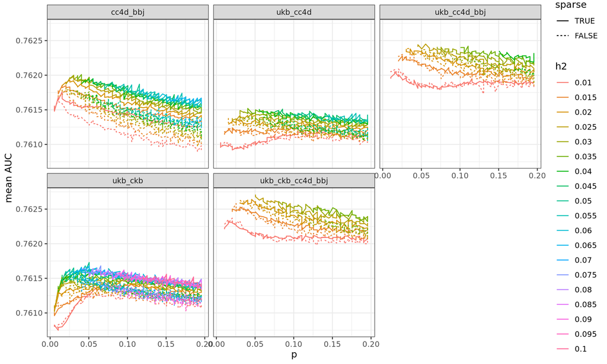